# Homework 6

Vasili Fokaidis

Read in data.

## Problem 1

Read in the data.

```r
homicide_df =
  read_csv("homicide_data/homicide-data.csv", na = c("", "NA", "Uknown")) %>%
  mutate(
    city_state = str_c(city, state, sep = ", "),
    victim_age = as.numeric(victim_age),
    resolution = case_when(
      disposition == "Closed without arrest" ~ 0,
      disposition == "Open/No arrest"        ~ 0,
      disposition == "Closed by arrest"      ~ 1)
  ) %>%
  filter(
    victim_race %in% c("White", "Black"),
    city_state != "Tulsa, AL") %>%
  select(city_state, resolution, victim_age, victim_race, victim_sex)
```

Start with one city.

```r
baltimore_df =
  homicide_df %>%
  filter(city_state == "Baltimore, MD")

glm(resolution ~ victim_age + victim_race + victim_sex,
    data = baltimore_df,
    family = binomial()) %>%
  broom::tidy() %>%
  mutate(
    OR = exp(estimate),
    CI_lower = exp(estimate - 1.96 * std.error),
    CI_upper = exp(estimate + 1.96 * std.error)
  ) %>%
  select(term, OR, starts_with("CI")) %>%
  knitr::kable(digits = 3)
```

| term | OR | CI_lower | CI_upper |
| --- | --- | --- | --- |
| (Intercept) | 1.363 | 0.975 | 1.907 |
| victim_age | 0.993 | 0.987 | 1.000 |
| victim_raceWhite | 2.320 | 1.648 | 3.268 |
| victim_sexMale | 0.426 | 0.325 | 0.558 |

Try this across cities.

```r
models_results_df =
  homicide_df %>%
  nest(data = -city_state) %>%
  mutate(
    models =
      map(.x = data, ~glm(resolution ~ victim_age + victim_race + victim_sex, data = .x, family = binomial())),
    results = map(models, broom::tidy)
  ) %>%
  select(city_state, results) %>%
  unnest(results) %>%
  mutate(
    OR = exp(estimate),
    CI_lower = exp(estimate - 1.96 * std.error),
    CI_upper = exp(estimate + 1.96 * std.error)
  ) %>%
  select(city_state, term, OR, starts_with("CI"))
```

## Problem 2

Read in data.

```r
bth_wt =
  read_csv("birthweight_data/birthweight.csv") %>%
  mutate(
    babysex = as.factor(babysex),
    mrace = as.factor(mrace),
    frace = as.factor(frace),
    bwt = bwt/453.592,
    frace = factor(frace, levels = c(1, 2, 3, 4, 8, 9), labels = c("white", "black", "asian", "puerto_rican", "other", "unknown")),
    mrace = factor(mrace, levels = c(1, 2, 3, 4, 8), labels = c("white", "black", "asian", "puerto_rican", "other")),
    babysex = recode(babysex, `1` = 0L, `2` = 1L)
  )
```

To clean the data, I turned `babysex`, `frace`, and `mrace` into factors, I converted `bwt` from grams to pounds, and I converted `frace` and `mrace` values to the corresponding races. And, I recoded `babysex` into a dummy variable where 0 = Male, and 1 = Female.

Let’s fit the model we care about (through backwards elimination)

```r
full_model =
  lm(bwt ~ ., data = bth_wt)

step(full_model, direction = "backward", trace = TRUE)
```

```
## Start:  AIC=-4403.92
## bwt ~ babysex + bhead + blength + delwt + fincome + frace + gaweeks +
##     malform + menarche + mheight + momage + mrace + parity +
##     pnumlbw + pnumsga + ppbmi + ppwt + smoken + wtgain
##
##
## Step:  AIC=-4403.92
## bwt ~ babysex + bhead + blength + delwt + fincome + frace + gaweeks +
##     malform + menarche + mheight + momage + mrace + parity +
##     pnumlbw + pnumsga + ppbmi + ppwt + smoken
##
##
## Step:  AIC=-4403.92
## bwt ~ babysex + bhead + blength + delwt + fincome + frace + gaweeks +
##     malform + menarche + mheight + momage + mrace + parity +
##     pnumlbw + ppbmi + ppwt + smoken
##
##
## Step:  AIC=-4403.92
## bwt ~ babysex + bhead + blength + delwt + fincome + frace + gaweeks +
##     malform + menarche + mheight + momage + mrace + parity +
##     ppbmi + ppwt + smoken
##
##            Df Sum of Sq    RSS     AIC
## - frace     4      0.60 1559.4 -4410.2
## - malform   1      0.01 1558.8 -4405.9
## - ppbmi     1      0.03 1558.9 -4405.8
## - momage    1      0.14 1559.0 -4405.5
## - mheight   1      0.33 1559.2 -4405.0
## - menarche  1      0.54 1559.4 -4404.4
## - ppwt      1      0.64 1559.5 -4404.1
## <none>                  1558.8 -4403.9
## - fincome   1      0.94 1559.8 -4403.3
## - parity    1      2.01 1560.8 -4400.3
## - mrace     3      4.22 1563.1 -4398.2
## - babysex   1      4.15 1563.0 -4394.4
## - gaweeks   1     22.42 1581.2 -4343.9
## - smoken    1     24.67 1583.5 -4337.7
## - delwt     1     38.93 1597.8 -4298.8
## - blength   1    496.00 2054.8 -3206.4
```

[output cut: 88 more lines]

```
##     mheight + mrace + parity + ppwt + smoken
##
##           Df Sum of Sq    RSS     AIC
## <none>                 1560.1 -4416.4
## - fincome  1      1.19 1561.3 -4415.1
## - parity   1      2.05 1562.2 -4412.7
## - babysex  1      4.11 1564.2 -4406.9
## - mheight  1      4.92 1565.0 -4404.7
## - ppwt     1     14.13 1574.2 -4379.2
## - gaweeks  1     22.66 1582.8 -4355.8
## - smoken   1     24.66 1584.8 -4350.3
## - delwt    1     39.55 1599.7 -4309.7
## - mrace    3     71.37 1631.5 -4228.2
## - blength  1    496.69 2056.8 -3218.3
## - bhead    1    518.99 2079.1 -3171.4
```

```
##
## Call:
## lm(formula = bwt ~ babysex + bhead + blength + delwt + fincome +
##     gaweeks + mheight + mrace + parity + ppwt + smoken, data = bth_wt)
##
## Coefficients:
##       (Intercept)            babysex              bhead            blength
##        -1.345e+01          6.296e-02          2.883e-01          1.652e-01
##             delwt            fincome            gaweeks            mheight
##         9.054e-03          7.011e-04          2.556e-02          1.454e-02
##        mraceblack         mraceasian  mracepuerto_rican             parity
##        -3.060e-01         -1.651e-01         -2.220e-01          2.123e-01
##              ppwt             smoken
##        -5.899e-03         -1.068e-02
```

```r
full_model =
  step(full_model, direction = "backward", trace = FALSE)

full_model %>% summary()
```

```
##
## Call:
## lm(formula = bwt ~ babysex + bhead + blength + delwt + fincome +
##     gaweeks + mheight + mrace + parity + ppwt + smoken, data = bth_wt)
##
## Residuals:
##     Min      1Q  Median      3Q     Max
## -2.4189 -0.4090 -0.0075  0.3839  5.1885
##
## Coefficients:
##                     Estimate Std. Error t value Pr(>|t|)
## (Intercept)       -1.345e+01  3.032e-01 -44.340  < 2e-16 ***
## babysex            6.296e-02  1.864e-02   3.378 0.000737 ***
## bhead              2.883e-01  7.598e-03  37.944  < 2e-16 ***
## blength            1.652e-01  4.451e-03  37.120  < 2e-16 ***
## delwt              9.054e-03  8.643e-04  10.475  < 2e-16 ***
## fincome            7.011e-04  3.853e-04   1.820 0.068844 .
## gaweeks            2.556e-02  3.223e-03   7.929 2.79e-15 ***
## mheight            1.454e-02  3.935e-03   3.694 0.000223 ***
## mraceblack        -3.060e-01  2.184e-02 -14.009  < 2e-16 ***
## mraceasian        -1.651e-01  9.329e-02  -1.770 0.076837 .
## mracepuerto_rican -2.220e-01  4.260e-02  -5.210 1.98e-07 ***
## parity             2.123e-01  8.893e-02   2.388 0.017004 *
## ppwt              -5.899e-03  9.422e-04  -6.261 4.20e-10 ***
## smoken            -1.068e-02  1.291e-03  -8.271  < 2e-16 ***
## ---
## Signif. codes:  0 '***' 0.001 '**' 0.01 '*' 0.05 '.' 0.1 ' ' 1
##
## Residual standard error: 0.6004 on 4328 degrees of freedom
## Multiple R-squared:  0.7181, Adjusted R-squared:  0.7173
## F-statistic: 848.1 on 13 and 4328 DF,  p-value: < 2.2e-16
```

Using backward elimination, the model was fitted using criterion based procedures (discrimination based on AIC values of various models). First, I developed a linear model containing all variables, then I ran the backward elimination with trace to evaluate the steps taken to deduce the final model. For example, the model without `wtgain` produced an AIC of -4403.92, and since this criterion based procedure aims for models with the lowest AIC, `wtgain` was removed, and so on. Finally, after many steps of this process, the model was produced.

Let’s look at the result…

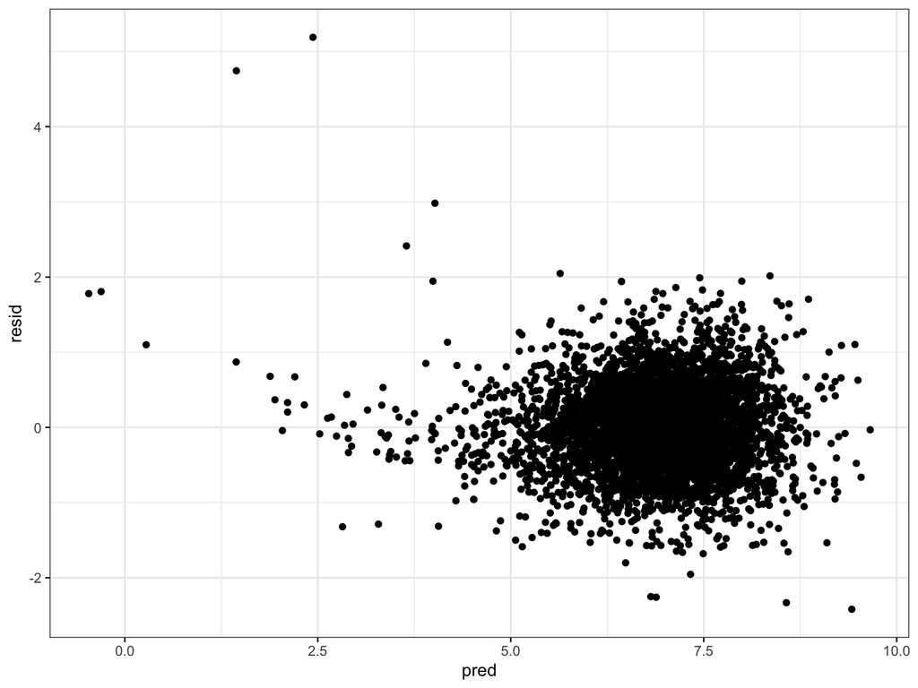

```r
 bth_wt %>%
  add_residuals(full_model) %>%
  add_predictions(full_model) %>%
  ggplot(aes(x = pred , y = resid)) +
  geom_point() +
  theme_bw()
```

The residuals are mostly well-behaved centering around 0. There is little deviation from the estimated regression line.

Compare your models. Make two others first.

```r
full_model %>% summary()
```

```
##
## Call:
## lm(formula = bwt ~ babysex + bhead + blength + delwt + fincome +
##     gaweeks + mheight + mrace + parity + ppwt + smoken, data = bth_wt)
##
## Residuals:
##     Min      1Q  Median      3Q     Max
## -2.4189 -0.4090 -0.0075  0.3839  5.1885
##
## Coefficients:
##                     Estimate Std. Error t value Pr(>|t|)
## (Intercept)       -1.345e+01  3.032e-01 -44.340  < 2e-16 ***
## babysex            6.296e-02  1.864e-02   3.378 0.000737 ***
## bhead              2.883e-01  7.598e-03  37.944  < 2e-16 ***
## blength            1.652e-01  4.451e-03  37.120  < 2e-16 ***
## delwt              9.054e-03  8.643e-04  10.475  < 2e-16 ***
## fincome            7.011e-04  3.853e-04   1.820 0.068844 .
## gaweeks            2.556e-02  3.223e-03   7.929 2.79e-15 ***
## mheight            1.454e-02  3.935e-03   3.694 0.000223 ***
## mraceblack        -3.060e-01  2.184e-02 -14.009  < 2e-16 ***
## mraceasian        -1.651e-01  9.329e-02  -1.770 0.076837 .
## mracepuerto_rican -2.220e-01  4.260e-02  -5.210 1.98e-07 ***
## parity             2.123e-01  8.893e-02   2.388 0.017004 *
## ppwt              -5.899e-03  9.422e-04  -6.261 4.20e-10 ***
## smoken            -1.068e-02  1.291e-03  -8.271  < 2e-16 ***
## ---
## Signif. codes:  0 '***' 0.001 '**' 0.01 '*' 0.05 '.' 0.1 ' ' 1
##
## Residual standard error: 0.6004 on 4328 degrees of freedom
## Multiple R-squared:  0.7181, Adjusted R-squared:  0.7173
## F-statistic: 848.1 on 13 and 4328 DF,  p-value: < 2.2e-16
```

```r
new_fit_0 = lm(bwt ~ blength + gaweeks, data = bth_wt)
summary(new_fit_0)
```

```
##
## Call:
## lm(formula = bwt ~ blength + gaweeks, data = bth_wt)
##
## Residuals:
##     Min      1Q  Median      3Q     Max
## -3.7690 -0.4748 -0.0252  0.4591  9.2348
##
## Coefficients:
##              Estimate Std. Error t value Pr(>|t|)
## (Intercept) -9.584973   0.215961  -44.38   <2e-16 ***
## blength      0.283417   0.004387   64.60   <2e-16 ***
## gaweeks      0.059628   0.003787   15.74   <2e-16 ***
## ---
## Signif. codes:  0 '***' 0.001 '**' 0.01 '*' 0.05 '.' 0.1 ' ' 1
##
## Residual standard error: 0.7346 on 4339 degrees of freedom
## Multiple R-squared:  0.5769, Adjusted R-squared:  0.5767
## F-statistic:  2958 on 2 and 4339 DF,  p-value: < 2.2e-16
```

```r
new_fit_1 = lm(bwt ~ bhead + blength + babysex + bhead*blength + bhead*babysex + blength*babysex + bhead*blength*babysex, data = bth_wt)
summary(new_fit_1)
```

```
##
## Call:
## lm(formula = bwt ~ bhead + blength + babysex + bhead * blength +
##     bhead * babysex + blength * babysex + bhead * blength * babysex,
##     data = bth_wt)
##
## Residuals:
##     Min      1Q  Median      3Q     Max
## -2.4978 -0.4198 -0.0228  0.3938  5.7716
##
## Coefficients:
##                         Estimate Std. Error t value Pr(>|t|)
## (Intercept)           -15.822186   2.788497  -5.674 1.49e-08 ***
## bhead                   0.400791   0.083895   4.777 1.84e-06 ***
## blength                 0.225152   0.057787   3.896 9.92e-05 ***
## babysex                14.054190   3.698846   3.800 0.000147 ***
## bhead:blength          -0.001221   0.001720  -0.710 0.478012
## bhead:babysex          -0.437382   0.112638  -3.883 0.000105 ***
## blength:babysex        -0.272873   0.077423  -3.524 0.000429 ***
## bhead:blength:babysex   0.008550   0.002329   3.670 0.000245 ***
## ---
## Signif. codes:  0 '***' 0.001 '**' 0.01 '*' 0.05 '.' 0.1 ' ' 1
##
## Residual standard error: 0.6343 on 4334 degrees of freedom
## Multiple R-squared:  0.6849, Adjusted R-squared:  0.6844
## F-statistic:  1346 on 7 and 4334 DF,  p-value: < 2.2e-16
```

Now cross validate using modelr.

```r
cv_df =
  crossv_mc(bth_wt, 100)

cv_df =
  cv_df %>%
  mutate(
    train = map(train, as_tibble),
    test = map(test, as_tibble)
  )

cv_df_1 =
  cv_df %>%
    mutate(
      full_model = map(.x = train, ~ lm(bwt ~ ., data = .x)),
      new_fit_0 = map(.x = train, ~ lm(bwt ~ blength + gaweeks, data = .x )),
      new_fit_1 = map(.x = train, ~ lm(bwt ~ bhead + blength + babysex + bhead*blength + bhead*babysex + blength*babysex + bhead*blength*babysex, data = .x))
    ) %>%
    mutate(
      rmse_full = map2(.x = full_model, .y = test, ~ rmse(model = .x, data = .y)),
      rmse_fit_0 = map2(.x = new_fit_0, .y = test, ~ rmse(model = .x, data = .y)),
      rmse_fit_1 = map2(.x = new_fit_1, .y = test, ~ rmse(model = .x, data = .y))
    )
```

What does this look like?

[figure not shown]

```r
cv_df_1 %>%
  select(starts_with("rmse")) %>%
  pivot_longer(
    everything(),
    names_to = "model",
    values_to = "rmse",
    names_prefix = "rmse_"
  ) %>%
  unnest() %>%
  ggplot(aes(x = model, y = rmse)) +
  geom_violin() +
  labs(
    title = "Residuals vs Fitted Values",
    y = "Residuals",
    x = "Fitted Values")
```

Compute average RMSEs.

```r
cv_df_1 %>%
  select(starts_with("rmse")) %>%
  pivot_longer(
    everything(),
    names_to = "model",
    values_to = "rmse",
    names_prefix = "rmse_"
  ) %>%
  unnest() %>%
  group_by(model) %>%
  summarize(avg_rmse = mean(rmse)) %>%
  knitr::kable()
```

| model | avg_rmse |
| --- | --- |
| fit_0 | 0.7386340 |
| fit_1 | 0.6390501 |
| full | 0.6058265 |

## Problem 3

Read in data.

```r
weather_df =
  rnoaa::meteo_pull_monitors(
    c("USW00094728"),
    var = c("PRCP", "TMIN", "TMAX"),
    date_min = "2017-01-01",
    date_max = "2017-12-31") %>%
  mutate(
    name = recode(id, USW00094728 = "CentralPark_NY"),
    tmin = tmin / 10,
    tmax = tmax / 10) %>%
  select(name, id, everything())
```

```
## using cached file: /Users/vasilifokaidis/Library/Caches/R/noaa_ghcnd/USW00094728.dly
```

```
## date created (size, mb): 2020-10-21 22:32:56 (7.525)
```

```
## file min/max dates: 1869-01-01 / 2020-10-31
```

Create bootstrap function. And, bootstrap 5000 times.

```r
boot_sample = function(df) {
  sample_frac(df, replace = TRUE)
}

boot_straps =
  tibble(
    strap_number = 1:5000,
    strap_sample = rerun(5000, boot_sample(weather_df))
  )
```

```r
r_sq =
  boot_straps %>%
  mutate(
    models = map(.x = strap_sample, ~lm(tmax ~ tmin, data = .x)),
    results = map(models, broom::glance)
  ) %>%
  select(strap_number, results) %>%
  unnest(results)

log_b0_b1 =
  boot_straps %>%
    mutate(
      models = map(.x = strap_sample, ~lm(tmax ~ tmin, data = .x)),
      results = map(models, broom::tidy)
    ) %>%
    unnest(results) %>%
    select(term, estimate) %>%
    pivot_wider(
      names_from = term,
      values_from = estimate
    ) %>%
    unnest() %>%
    rename(
      intercept = `(Intercept)`
    ) %>%
    summarize(
      log_b0_b1 = log(intercept/tmin),
      strap_number = c(1:5000)
    )

boot_results =
  right_join(x = r_sq, y = log_b0_b1, by = "strap_number", all = TRUE)

boot_results
```

```
## # A tibble: 5,000 x 14
##    strap_number r.squared adj.r.squared sigma statistic   p.value    df logLik
##           <int>     <dbl>         <dbl> <dbl>     <dbl>     <dbl> <dbl>  <dbl>
##  1            1     0.909         0.909  2.93     3628. 4.58e-191     1  -909.
##  2            2     0.920         0.920  2.81     4201. 1.25e-201     1  -893.
##  3            3     0.913         0.913  2.88     3825. 7.42e-195     1  -903.
##  4            4     0.910         0.910  3.03     3679. 4.60e-192     1  -922.
##  5            5     0.905         0.905  3.02     3474. 5.82e-188     1  -921.
##  6            6     0.914         0.914  2.82     3877. 7.78e-196     1  -895.
##  7            7     0.906         0.906  3.01     3491. 2.69e-188     1  -919.
##  8            8     0.920         0.920  2.91     4170. 4.22e-201     1  -906.
##  9            9     0.911         0.910  2.97     3700. 1.85e-192     1  -914.
## 10           10     0.909         0.909  2.98     3630. 4.24e-191     1  -916.
## # … with 4,990 more rows, and 6 more variables: AIC <dbl>, BIC <dbl>,
## #   deviance <dbl>, df.residual <int>, nobs <int>, log_b0_b1 <dbl>
```

Plot distributions of estimates.

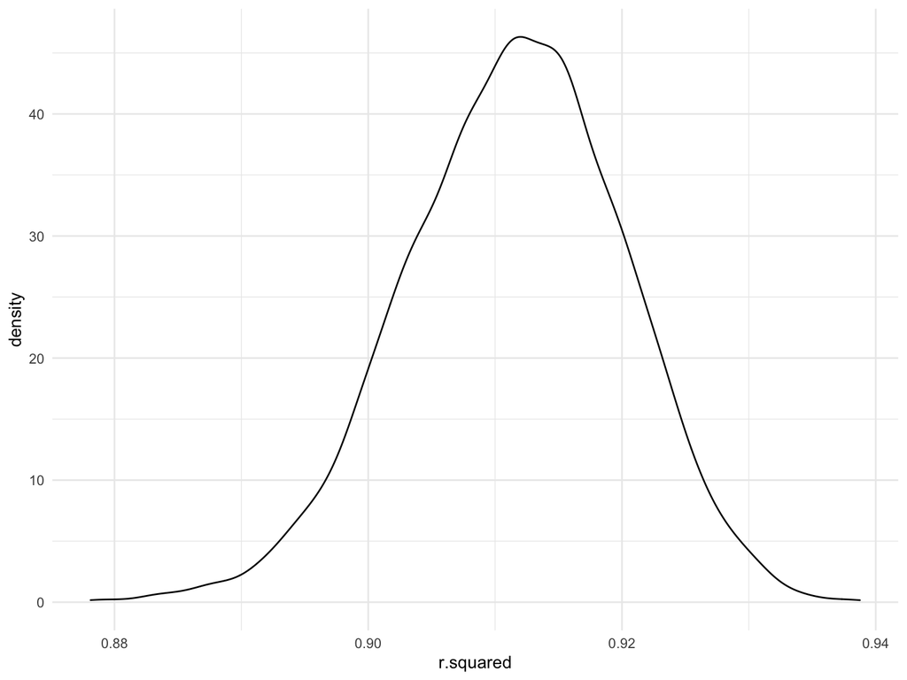

```r
par(mfrow = c(1, 2))

boot_results %>%
  ggplot(aes(x = r.squared)) +
  geom_density()
```

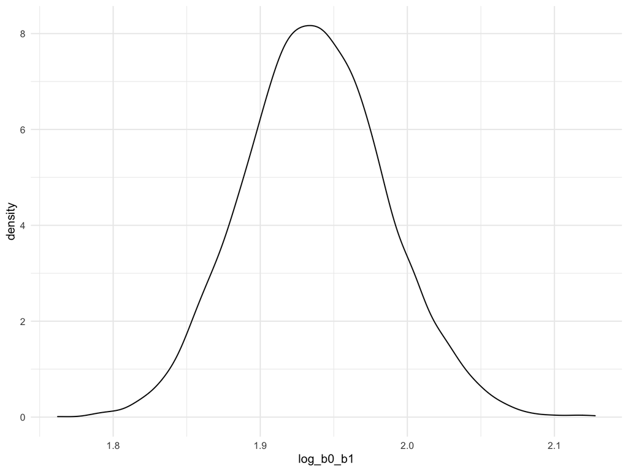

```r
boot_results %>%
  ggplot(aes(x = log_b0_b1)) +
  geom_density()
```

```r
boot_results %>%
  select(r.squared, log_b0_b1) %>%
  pivot_longer(
    everything(),
    names_to = "term",
    values_to = "estimate"
  ) %>%
  group_by(term) %>%
  summarize(
    ci_lwr = quantile(estimate, 0.025),
    ci_upr = quantile(estimate, 0.975)
  ) %>%
  knitr::kable()
```

| term | ci_lwr | ci_upr |
| --- | --- | --- |
| log_b0_b1 | 1.8460384 | 2.0346601 |
| r.squared | 0.8940749 | 0.9273247 |